# Clase 1: Comandos Básicos y Exploración de Datos

Esta clase está diseñada para enseñarte los comandos básicos en R, incluyendo la creación de variables, tablas y la importación de bases de datos. Además, aprenderás a explorar y analizar tus datos de manera apropiada, siguiendo la metodología de Zuur **et al**. (2010). Con el tiempo, podrás utilizar estas habilidades básicas en R para realizar análisis más complejos y obtener resultados acordes a tu pregunta de investigación.

### Contenido

#### Operaciones básicas

- Adición (suma)

```r
2 + 2
```

```
## [1] 4
```

- Sustracción (resta)

```r
2 - 2
```

```
## [1] 0
```

- Multiplicación

```r
2 * 2
```

```
## [1] 4
```

- División

```r
2 / 2
```

```
## [1] 1
```

- Raíz cuadrada

Observe que para la raíz cuadrada se utiliza el comando `sqrt` y el valor del que se quiere obtener la raíz cuadrada se coloca dentro de los paréntesis `( )`.

```r
sqrt(2)
```

```
## [1] 1.414214
```

Ahora que conocemos algunas de las operaciones básicas, podemos resolver algunos ejercicios.

**Ejercicio 1**

Utilizando la ecuación de regresión linear, para la cual la `pendiente` tiene un valor de 0.3 y el `intercepto` un valor de 34.5, resolver cuanto sería el valor de `y` si `x` vale 36.4.

$y = intercepto + slope(x)$

Solución:

```r
34.5 + 0.3*36.4
```

```
## [1] 45.42
```

#### Creación de variables

Comencemos creando variables numéricas con un único valor

```r
x <- 5 # En este caso, x tendrá el valor de 5
```

```r
y <- -3 # En este caso, y tendrá el valor de -3
```

Si queremos crear variables numéricas con varios valores, tendremos que crear un vector utilizando el comando `c()`, en donde cada valor estará separa por coma.

```r
Peso <- c(12.5, 23, 12.6, 18, 7, 18.3, 23, 40, 21,8)
```

Observe que en este caso las comas se parados los valores, y los puntos solo se utilizan para las cifras decimales. La variable `Peso` tendrá 10 observaciones.

Otra forma de crear un vector es utilizando el signo `:` entre los valores del inicio y final.

```r
Altura <- c(1:1000)
```

En este caso la variable `Altura` tendrá 1000 observaciones

Ahora, ¿cómo podemos crear una variable con números aleatorios?, como podemos crear una variable con distribución normal?

**Variable con numeros alatorios**

Primero podríamos utilizar el comando `sample()` para crear números aleatorios sin una distribución en especifica, dando el número de inicio y final, y la cantidad de observaciones que deseamos.

```r
Aleatorios <- sample(1:1000, size = 50)
```

En este ejemplo observe que, 1 y 1000 es el rango entre el cual estarán 50 observaciones.

**Variable con distribucion normal**

Podemos crear variables con una distribución normal utilizando el comando `rnorm()`, en este caso tendremos que especificar la media y la desviación estándar.

```r
Dnormal <- rnorm(50, mean = 30, sd = 2.5)
```

Para este ejemplo, hemos creado 50 observaciones, con una media de 30 y una desviación estándar de 2.5

El siguiente paso es la creación de variables categorías, variables que incluyen `categorias`. Para crear una variable de categorías tendremos que colocar cada observación entre comillas `" "`

```r
Variabley <- "y"
```

En este ejemplo la `variabley` solo tiene la observación `y`. Si quermos más observaciones podemos utilizar el comando `c()`.

```r
Seccion <- c("1A", "1B", "3A", "2B", "2A", "3A")
```

#### Creación de tablas

Ya que aprendimos como crear variables numéricas y categóricas, ahora podemos crear tablas. Para crear una tabla en R debemos de asegurar que nuestras variables presenten la misma cantidad de observaciones.

**Creación de tabla con 10 observaciones**

En este primer paso, crearemos tres variables que representarán nuestros datos. Cada variable contiene diferentes tipos de información:

Temperatura: valores numéricos enteros generados aleatoriamente entre 20 y 35. Riqueza: valores numéricos continuos generados a partir de una distribución normal, con media de 5 y desviación estándar de 3. Franja: variable categórica que indica grupos o categorías (A, B y C).

```r
Temperatura <- sample(20:35, 10)

Riqueza <- rnorm(10, mean = 5, sd= 3)

Franja <- c("A", "A", "C", "C", "A", "B", "B", "B", "A", "C")
```

Una vez que hemos creado las variables, el siguiente paso es combinarlas en una sola estructura de datos. Para esto utilizamos la función `data.frame()`, que permite organizar múltiples variables en forma de tabla (filas y columnas).

Cada fila representa una observación, y cada columna corresponde a una variable.

```r
Tabla1 <- data.frame(Franja, Temperatura, Riqueza)
```

Exploración de la tabla

Finalmente, podemos visualizar la tabla creada para verificar que los datos se han organizado correctamente. Esto nos permite revisar la estructura, los valores y detectar posibles errores.

| Franja | Temperatura | Riqueza |
| --- | --- | --- |
| A | 31 | 7.7560823 |
| A | 35 | 8.2212680 |
| C | 28 | -1.3942946 |
| C | 23 | 4.9420117 |
| A | 22 | 2.5776807 |
| B | 29 | 6.7241377 |
| B | 25 | 7.1209861 |
| B | 30 | 4.3449053 |
| A | 27 | 0.8214451 |
| C | 21 | 7.6120933 |

#### Cargar una base de datos

Para cargar una base de datos desde nuestro computador, es necesario conocer la ubicación exacta del archivo dentro de nuestro sistema. En el caso de trabajar dentro de un proyecto de R, es recomendable organizar los archivos en carpetas (por ejemplo, una carpeta llamada `data`).

Supongamos que tenemos un archivo llamado `bird.sta` almacenado en la carpeta data de nuestro proyecto. Si este archivo está delimitado por comas, podemos utilizar la función `read.csv()` para importarlo a R.

**Ejemplo para cargar una base de datos**

```r
Aves.sta <- read.csv("data/bird.sta.csv")
```

Observe que el nombre de la base de datos es `bird.sta`, el formato es `.csv` y se encuentra en la carpeta `data`, esta base de datos fue guardada en `Aves.sta` en nuestro ambiente en R

#### Estadística descriptiva

Referencia: [Statistics With Applications to the Biological and Health Sciences](https://www.cabidigitallibrary.org/doi/full/10.5555/19712702614)

El área de la estadística descriptiva se ocupa de resumir y caracterizar conjuntos de observaciones mediante el uso de herramientas gráficas, tablas y medidas numéricas. A través de estos recursos se pueden identificar distintas propiedades de los datos, como la frecuencia con que aparecen determinados valores, la identificación de un valor típico o representativo, el grado de variabilidad dentro de las observaciones y la relación existente entre dos o más variables.

Es importante señalar que la estadística descriptiva no tiene como objetivo principal derivar conclusiones o implicaciones generales a partir de los datos. Su función es organizar la información y resaltar sus características esenciales, de manera que posteriormente sea posible interpretar los datos y extraer conclusiones en etapas posteriores del análisis.

Sin embargo, las conclusiones a las que se llegue dependerán en gran medida de cómo se seleccionen y utilicen las estadísticas descriptivas. Una elección inadecuada puede conducir a inferencias científicas erróneas. Un ejemplo de esto ocurre cuando se seleccionan únicamente ciertas partes del conjunto de datos y se excluyen aquellas que no coinciden con las ideas preconcebidas del investigador sobre cómo debería comportarse la naturaleza, lo cual puede sesgar la interpretación de los resultados.

*Medidas de posición o de tendencia central*

**Media Aritmetica**

La medida de tendencia central más simple y, en muchos sentidos, la más evidente es el promedio de las observaciones dentro de un grupo. Sin embargo, el término *promedio* puede resultar ambiguo, ya que existen diferentes tipos de promedios y no siempre es claro a cuál se está haciendo referencia.

Para evitar esta confusión, en estadística se utiliza el término *media aritmética* para referirse específicamente a la suma de todas las observaciones de un conjunto de datos dividida entre el número total de observaciones. De esta manera se distingue con precisión de otros tipos de promedios. Por ello, cuando en estadística se usa simplemente el término media, generalmente se está haciendo referencia a la media aritmética.

Leer: “Comparación de la media aritmética y la media geométrica como medidas de tendencia central en poblaciones de nematodos en ganado”

Para los siguientes ejemplos utilizaremos la base de datos `penguins` del paquete [palmerpenguins](https://allisonhorst.github.io/palmerpenguins/articles/intro.html)

1. Cargar la base de datos penguins

Primero debemos cargar el paquete `palmerpenguins`

```r
library(palmerpenguins)
```

Una vez cargada el paquete podemos cargar a la base de datos `penguins`

```r
data("penguins")
```

2. Calcular la media de cada columna del data frame

```r
sapply(penguins[, 3:6], mean, na.rm = TRUE)
```

```
##    bill_length_mm     bill_depth_mm flipper_length_mm       body_mass_g
##          43.92193          17.15117         200.91520        4201.75439
```

Observe que que estamos seleccionando la columna 3 a la 6 (ya que contienen variables numericas), y el na.rm = TRUE, es para que reconosca que existen NA en nuestra base de datos.

3. Calcular la media de la masa de los pingüinos para cada especie

```r
tapply(penguins$body_mass_g, penguins$species, mean, na.rm =TRUE )
```

```
##    Adelie Chinstrap    Gentoo
##  3700.662  3733.088  5076.016
```

Observe que que estamos seleccionando la columna `body_mass_g` para estimar la media condicionada por la variable `species`, el nar.rm = TRUE, es para que reconosca que existen NA en nuestra base de datos.

**Mediana**

Otra medida de tendencia central muy utilizada es la mediana, que corresponde al valor que ocupa la posición central cuando las observaciones se ordenan de menor a mayor.

El procedimiento descrito es adecuado cuando el conjunto de datos tiene un número impar de observaciones, pero evidentemente no puede aplicarse directamente cuando el número de observaciones es par.

Por ejemplo, supongamos el siguiente conjunto de datos: 2, 3, 5, 8

Al haber cuatro observaciones, no existe un único valor central. En este caso, la mediana se obtiene calculando el promedio de los dos valores centrales. Primero identificamos esos valores (3 y 5) y luego calculamos su media. Por lo tanto, la mediana de este conjunto de datos es 4. De esta forma, la mediana siempre divide el conjunto de datos ordenados en dos partes iguales: la mitad de las observaciones quedan por debajo y la otra mitad por encima de este valor.

```r
tapply(penguins$bill_length_mm,
       penguins$species,
       median,
       na.rm = TRUE)
```

```
##    Adelie Chinstrap    Gentoo
##     38.80     49.55     47.30
```

**Moda**

Otra medida común de tendencia central es la moda. La moda es el valor que aparece con mayor frecuencia en un conjunto de observaciones.

Por ejemplo, en la serie de conteos radiológicos 1, 2, 2, 4, 5, 9, la moda sería 2, ya que es el valor que se repite con mayor frecuencia. Conjuntos de observaciones como este se llaman unimodales, porque tienen una sola moda.

Sin embargo, si hubiéramos registrado otra observación con valor 4, entonces tanto el 2 como el 4 aparecerían dos veces en el conjunto resultante de siete observaciones. En ese caso, el conjunto se denominaría bimodal.

Podemos calcular la moda del peso (body_mass_g) de los pingüinos por especie y sexo usando R. Como R base no tiene una función de moda incorporada, primero definimos una función simple que devuelva la moda, y luego la aplicamos a cada grupo.

Función para calcular la moda

```r
moda <- function(x) {
  ux <- unique(x)
  ux[which.max(tabulate(match(x, ux)))]
}
```

Aplicar la función por especie y sexo usando tapply

```r
tapply(penguins$body_mass_g,
       list(penguins$species, penguins$sex),
       moda)
```

```
##           female male
## Adelie      3450 3900
## Chinstrap   3700 4050
## Gentoo      4700 5550
```

*Medidas de variabilidad*

**Rango**

El rango es una medida de variabilidad que indica la diferencia entre el valor máximo y el valor mínimo de un conjunto de datos. Nos da una idea rápida de qué tan dispersos están los datos, aunque no considera cómo se distribuyen los valores intermedios.

Supongamos que tenemos las siguientes alturas de cinco estudiantes (en cm):

160, 165,170,175,180

Valor máximo = 180

Valor mínimo = 160

Rango= 180−160 = 20

Esto significa que las alturas varían en 20 cm entre el estudiante más bajo y el más alto.

**Varianza**

La varianza es una medida de variabilidad o dispersión que indica qué tanto se alejan los valores de un conjunto de datos respecto a su media. Mientras mayor sea la varianza, más dispersos están los datos; mientras menor sea, más cercanos están a la media.

Fórmula para una población:

$$\sigma^2 = \frac{\sum_{i=1}^{N} \left(x_i - \mu \right)^2}{N}$$

**Desviación estándar**

La desviación estándar es una medida de dispersión que indica qué tanto se alejan los valores de un conjunto de datos respecto a su media. Mientras que la varianza nos da la dispersión en unidades al cuadrado, la desviación estándar devuelve la dispersión en las mismas unidades que los datos originales, lo que facilita su interpretación.

Una desviación estándar pequeña indica que los valores están muy cercanos a la media.

Una desviación estándar grande indica que los valores están muy dispersos alrededor de la media. Por ejmplo una desviación estándar de 3.16 significa que los valores, en promedio, se alejan de la media aproximadamente 3.16 unidades.

Desviación estándar de una población

$$\sigma = \sqrt{\frac{\sum_{i=1}^{N} \left(x_i - \mu \right)^2}{N}}$$

**Error estándar**

El error estándar es una medida de la precisión con la que la media muestral estima la media poblacional. Mientras que la desviación estándar mide la variabilidad de los datos individuales, el error estándar mide la variabilidad de la media si se repitieran múltiples muestras de la misma población.

Fórmula:

Para una muestra:

$$SE = \frac{s}{\sqrt{n}}$$

Podemos calcular el error estándar (SE) de la masa corporal (body_mass_g) por especie y sexo usando

Función para calcular el error estándar

```r
SE <- function(x) {
  x <- na.omit(x)
  sd(x) / sqrt(length(x))
}
```

Aplicar por especie y sexo

```r
tapply(penguins$body_mass_g,
       list(penguins$species, penguins$sex),
       SE)
```

```
##             female     male
## Adelie    31.52856 40.59122
## Chinstrap 48.93436 62.10608
## Gentoo    36.97304 40.09585
```

**Percentiles, cuartiles y rangos percentílicos**

Los percentiles son medidas de posición que dividen un conjunto de datos ordenados en 100 partes iguales. Cada percentil indica el valor por debajo del cual se encuentra un cierto porcentaje de las observaciones. Por ejemplo, el percentil 25 (P25) es el valor que deja el 25% de los datos por debajo y el 75% por encima.

Los cuantiles son generalizaciones de los percentiles. Un cuantil de orden q (donde 0<q<1) es el valor que deja una fracción q de los datos por debajo. Por ejemplo:

El cuartil 1 (Q1) es equivalente al percentil 25

La mediana (Q2) es equivalente al percentil 50

El cuartil 3 (Q3) es equivalente al percentil 75

Los rangos percentílicos (percentile ranks) indican el porcentaje de observaciones que se encuentran por debajo de un valor específico dentro del conjunto de datos. Por ejemplo, si un valor de glucosa tiene un rango percentílico del 90%, significa que el 90% de los valores medidos son menores que este valor.

Estas medidas son útiles en biología y ciencias de la salud porque permiten:

- Comparar valores individuales con respecto a la distribución de la población.
- Identificar valores extremos o atípicos.
- Evaluar el crecimiento, la presión arterial, o parámetros clínicos en función de la población de referencia.

En resumen, los percentiles y cuantiles proporcionan una forma de describir la posición relativa de los datos dentro de un conjunto ordenado, mientras que los rangos percentílicos permiten expresar esa posición en términos de porcentaje de la población.

```r
pesos <- na.omit(penguins$body_mass_g)

quantile(pesos, probs = c(0.1, 0.25, 0.5, 0.75, 0.9))
```

```
##  10%  25%  50%  75%  90%
## 3300 3550 4050 4750 5400
```

Supongamos que queremos el rango percentílico del pingüino que pesa 4000 g:

```r
mean(pesos < 4000) * 100
```

```
## [1] 48.24561
```

Esto devuelve el porcentaje de pingüinos que pesan menos de 4000 g.

#### Exploración de datos (Zuur et al. 2010)

De acuerdo con Zuur et al. (2010), hay seis pasos que se deben seguir en la exploración de datos con el fin de facilitar la elección del método estadístico a utilizar.

Para este ejercicio utilizaremos la base de datos del estudio de O’Neill et al. (2018).

para cargar la base de datos utilizares el comando:

```r
cyanistes <- read.table("data/cyanistes.txt", header = TRUE)
```

Comencemos inspeccionando la estructura de la base de datos con la función ‘str()’

```r
str(cyanistes)
```

```
## 'data.frame':    438 obs. of  7 variables:
##  $ id    : chr  "B1" "B10" "B111" "B112" ...
##  $ zone  : chr  "B" "B" "B" "B" ...
##  $ year  : int  2002 2001 2002 2002 2001 2001 2002 2002 2002 2002 ...
##  $ multi : chr  "yes" "yes" "no" "no" ...
##  $ height: num  2.7 2 2 1.9 2.1 2.5 1.9 2.2 2.4 2.3 ...
##  $ day   : int  8 25 10 6 28 23 10 10 11 7 ...
##  $ depth : num  0.33 0.25 0.2 0.25 0.33 0.4 0.2 0.2 0.2 0.33 ...
```

¿Existen valores nulos (NAs) en el conjunto de datos?

```r
colSums(is.na(cyanistes))
```

```
##     id   zone   year  multi height    day  depth
##      0      0      0      0      0      0      0
```

##### 1) Valores extremos (outliers) en la variable respuesta y predictora.

Análisis visual:

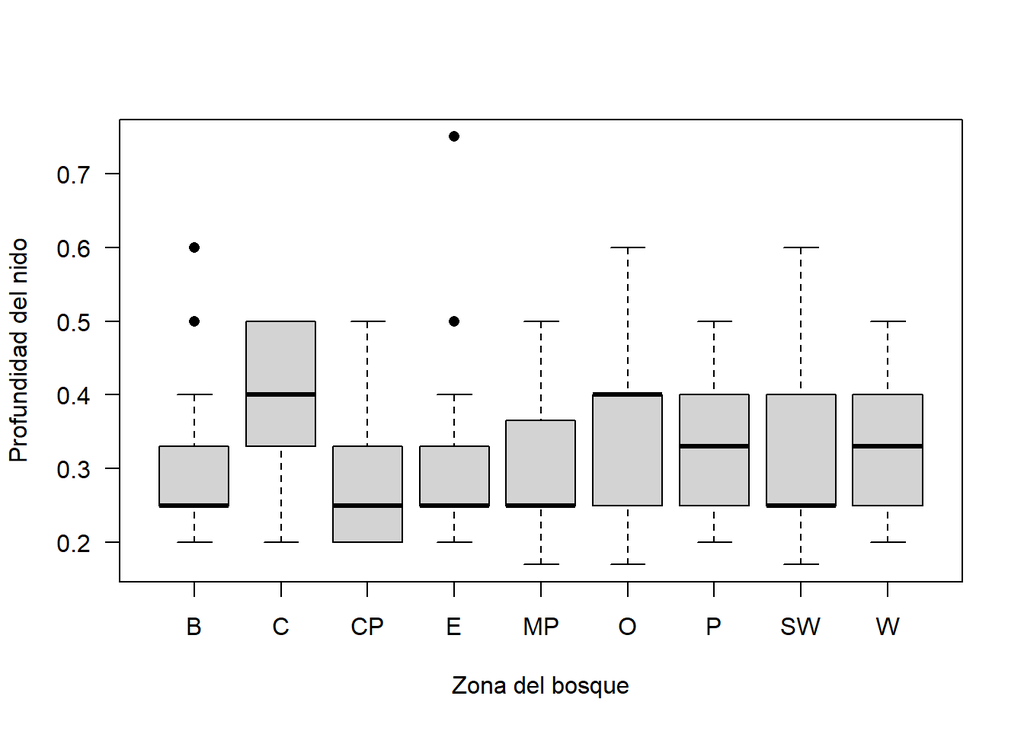

```r
boxplot(depth ~ zone,
        ylab= "Profundidad del nido",
        xlab = "Zona del bosque",
        data= cyanistes,
        outpch = 16,
        las= 1)
```

Análisis estadístico:

Para este ejercicio, utilizaremos el paquete `outliers`. Los **::** después de outliers indican que usaremos la función `grubbs.test` del paquete `outliers` sin necesidad de cargarlo previamente.

```r
outliers::grubbs.test(cyanistes$depth, type = 10)
```

```
##
##  Grubbs test for one outlier
##
## data:  cyanistes$depth
## G = 4.13755, U = 0.96074, p-value = 0.006479
## alternative hypothesis: highest value 0.75 is an outlier
```

```r
outliers::grubbs.test(cyanistes$height, type = 11)
```

```
##
##  Grubbs test for two opposite outliers
##
## data:  cyanistes$height
## G = 8.64561, U = 0.91371, p-value < 2.2e-16
## alternative hypothesis: 0.6 and 3.5 are outliers
```

```r
outliers::grubbs.test(cyanistes$day, type = 10)
```

```
##
##  Grubbs test for one outlier
##
## data:  cyanistes$day
## G = 2.41610, U = 0.98661, p-value = 1
## alternative hypothesis: highest value 37 is an outlier
```

##### 2) Normalidad y homogeneidad en la variable respuesta.

Un supuesto de algunas pruebas estadísticas es que la variable respuesta sigue una distribución normal. Para verificar este supuesto, se puede utilizar una prueba de normalidad, como la prueba de Shapiro-Wilk. La hipótesis nula de esta prueba establece que los datos se distribuyen normalmente. Si el valor p es menor que 0.05 (p < 0.05), se rechaza la hipótesis nula.

```r
shapiro.test(cyanistes$depth)
```

```
##
##  Shapiro-Wilk normality test
##
## data:  cyanistes$depth
## W = 0.89872, p-value < 2.2e-16
```

```r
ks.test(cyanistes$depth, "pnorm")
```

```
##
##  Asymptotic one-sample Kolmogorov-Smirnov test
##
## data:  cyanistes$depth
## D = 0.56784, p-value < 2.2e-16
## alternative hypothesis: two-sided
```

La homogeneidad de varianzas es otro supuesto importante en muchas pruebas estadísticas. Para visualizar la homogeneidad de varianzas en una variable categórica, se puede utilizar un gráfico de caja. Sin embargo, un gráfico de dispersión es más adecuado para visualizar la homogeneidad en variables numéricas.

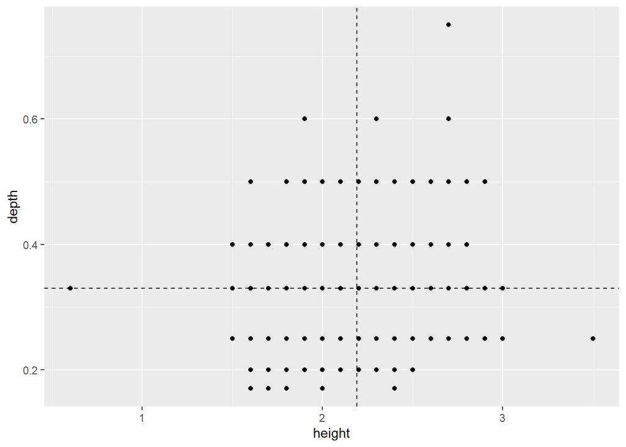

```r
library(ggplot2)
ggplot(data= cyanistes, aes(x= height, y= depth)) +
  geom_point()+
  geom_hline(yintercept = 0.33, linetype = "dashed")+
  geom_vline(xintercept = 2.19, linetype = "dashed")
```

Existen varias pruebas estadísticas para evaluar la homogeneidad de varianzas, como la prueba de Bartlett, la prueba F y la prueba de Levene.

```r
car::leveneTest(depth ~ zone, data = cyanistes)
```

```
## Levene's Test for Homogeneity of Variance (center = median)
##        Df F value Pr(>F)
## group   8  0.6051 0.7738
##       429
```

##### 3) Exceso de ceros en la variable respuesta.

Los ceros no pueden ser omitidos de un conjunto de datos; sin embargo, un exceso de ceros en la variable respuesta, conocido como inflación de ceros, puede causar problemas en los análisis. Una forma de evaluar la inflación de ceros es calculando el porcentaje de ceros en la variable:

```r
sum(cyanistes$depth == 0, na.rm = TRUE) * 100 / nrow(cyanistes)
```

```
## [1] 0
```

En este caso, no tenemos problemas con los ceros. Sin embargo, de presentarse, tendríamos que buscar alternativas para manejarlos, lo cual abordaremos más adelante.

##### 4) Multicolinealidad entre variables predictoras.

La multicolinealidad entre variables predictoras se refiere a una situación en la que dos o más variables independientes en un modelo de regresión están altamente correlacionadas entre sí. Esto puede dificultar la estimación de los coeficientes del modelo, ya que hace que sea complicado determinar el efecto individual de cada variable en la variable dependiente. La multicolinealidad puede inflar los errores estándar de los coeficientes, lo que lleva a inferencias estadísticas poco confiables, como valores p engañosos y una disminución en la capacidad predictiva del modelo.

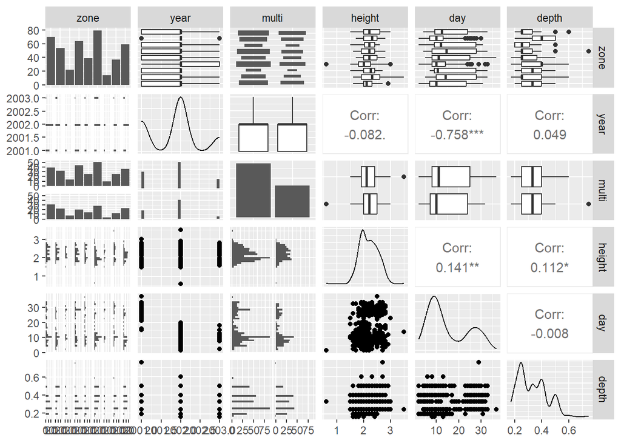

```r
GGally::ggpairs(cyanistes[,2:7])
```

##### 5) Relaciones entre variables respuesta y predictoras.

Las relaciones entre variables respuesta y predictoras se refieren a cómo la variable dependiente (respuesta) se ve afectada por las variables independientes (predictoras) en un conjunto de datos. Examinar estas relaciones es fundamental en la exploración de datos porque permite identificar patrones, tendencias y correlaciones que pueden influir en el comportamiento de la variable respuesta. Comprender estas relaciones ayuda a construir modelos predictivos más precisos, a formular hipótesis y a guiar la interpretación de resultados, facilitando así la toma de decisiones informadas en el análisis estadístico y en la investigación.

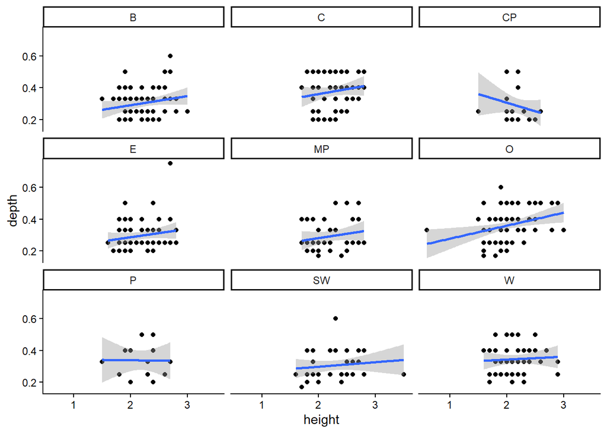

```r
ggplot(data = cyanistes, aes(x = height, y = depth)) +
  geom_point() +
  geom_smooth(method = lm) +
  facet_wrap(~zone) +
  theme_classic()
```

##### 6) Independencia en las observaciones de la variable respuesta.

La independencia en las observaciones de la variable respuesta se refiere a la suposición de que cada observación en el conjunto de datos es independiente de las demás. Esto significa que el valor de una observación no debe influir en el valor de otra. La independencia es crucial en el análisis estadístico porque garantiza que las inferencias y los resultados sean válidos. Si las observaciones no son independientes, puede haber una correlación no reconocida entre ellas, lo que puede conducir a errores en la estimación de parámetros, aumento de la varianza de los errores y, en última instancia, a conclusiones incorrectas sobre las relaciones entre variables. Por lo tanto, verificar la independencia de las observaciones es un paso esencial en la exploración de datos y en la construcción de modelos estadísticos.

#### Asignación 1

Esta asignación tiene como objetivo reforzar los conceptos aprendidos en clase. En primer lugar, deberá instalar el paquete palmerpenguins. Una vez instalado, deberá cargarlo y acceder a la base de datos penguins.

Utilizando esta base de datos, seleccione una variable y calcule su media y desviación estándar. Además, deberá practicar los pasos de exploración de datos descritos por Zuur et al. (2010).

```r
library(palmerpenguins)
data(penguinds)

head(penguins)
```

```
## # A tibble: 6 × 8
##   species island    bill_length_mm bill_depth_mm flipper_length_mm body_mass_g
##   <fct>   <fct>              <dbl>         <dbl>             <int>       <int>
## 1 Adelie  Torgersen           39.1          18.7               181        3750
## 2 Adelie  Torgersen           39.5          17.4               186        3800
## 3 Adelie  Torgersen           40.3          18                 195        3250
## 4 Adelie  Torgersen           NA            NA                  NA          NA
## 5 Adelie  Torgersen           36.7          19.3               193        3450
## 6 Adelie  Torgersen           39.3          20.6               190        3650
## # ℹ 2 more variables: sex <fct>, year <int>
```